# Coursera Finance Specialisation (U Michigan) M2 – Risk and Return Week 4 – Diversification and CAPM

Joe Nguyen

06 December 2015

## 4.1 Diversification: Two Assets

### Some Definitions

#### Return of portfolio:

$R_p = x_a R_a + x_b R_b$ where $(x_a,\, x_b)$ is proportion (of investment) in security $a$ and $b$. Portfolio return is a linear combination.

#### Risk of two-asset portfolio:

$\begin{align} \sigma^2(R_p) = \sigma_p^2 &= x_a^2 \sigma_a^2 + x_b^2 \sigma_b^2 + 2 x_a x_b \sigma_{ab} \\ &= x_a^2 \sigma_a^2 + x_b^2 \sigma_b^2 + 2 x_a x_b \rho_{ab} \sigma_a \sigma_b \end{align}$ Since $\sigma_{ab} = \sigma_{ba}$, we have 2 of the last term. Risk is maximum when $a$ and $b$ are totally correlated ($\rho_{ab} = 1$) and minimum when they are uncorrelated ($\rho_{ab} = 0$) (or when they’re negatively correlated? ($\rho_{ab} = -1$))

## 4.2 Diversification: Two Assets Intuition

When the two securities are totally correlated ($\rho_{ab} = 1$), there is no benefit in diversification; we may as well invest in just one of them.

If there was perfect correlation ($\rho_{ab} = 1$), the main source of risk is market (instead of specific).

Most likely correlation between 2 assets is around $\rho_{ab} = 0.5$. This is because the assets move with the market, but are are also unique.

A correlation of $\rho_{ab} = -0.5$ is much less likely simply because the assets should be related with each other through the market.

## 4.3 Diversification: Bottom Line

- Was combining Google and Yahoo a good choice?

Given other choices (opportunity cost), probably not because Google and Yahoo are competitors in the same space, and so their correlation would be positive high. That is, our diversification with these assets is low.

- Would Google and Boeing be a better choice?

Yes, probably better (not neccesarily the optimal) because they’re not highly correlated, and so primarly risk is *specific* (instead of *macro/market*). Our diversification is higher.

### Diversification: Three assets, Intuition

- Three securities, Google, Boeing, Merck (pharmaceutical)
- Portfolio risk:

$\sigma^2(R_p) = \sigma_p^2 = x_a^2 \sigma_a^2 + x_b^2 \sigma_b^2 + x_c^2 \sigma_c^2 + 2 x_a x_b \sigma_{ab} + 2 x_a x_c \sigma_{ac} + 2 x_b x_c \sigma_{bc}$

- 3 unique variances $(\sigma_{ab},\, \sigma_{ac},\, \sigma_{bc})$
- 6 relationships, 3 unique relationships
- 9 total factors affecting $\sigma_p$: 3 variances, 6 relationships; or $= 3^2$

#### S&P 500

- $500^2 = 250,000$ total factors
- 500 unique variances
- $250,000 - 500 = 249,500$ relationships

or

```r
# Unique relationships
choose(500,2)
```

```
## [1] 124750
```

```r
# Total relations
2 * choose(500,2)
```

```
## [1] 249500
```

### Bottom Line

- Variance of an asset determines risk faced by you only if you hold one (or very few) assets; you face both systematic and specific risks of that/those asset(s)
- Variance of any asset is **unimportant** when held in a large (assets > 30) diversified portfolio
- Specific risks are diversified (cancel each other); **only relations among the assets matter**
- An asset’s contribution to a portfolio’s risk is determind by its relations with all other assets in the portfolio
- All relations are due to common/systematic/market affects!

#### Relationship between number of stocks and portfolio risk (sd)

**Assumptions:**

- Equal investment in all $n$ stocks (all weights $x_i = 1 / n$)
- Risk of stocks are random uniform $\sigma_i \sim \text{unif}(1,5)$
- Stocks are chosen randomly such that their pair-wise correlation are uniform random $\rho_{ij} \sim \text{unif}(0,1)$
  - The correlation range is kept above 0 assuming negative correlation is very rare

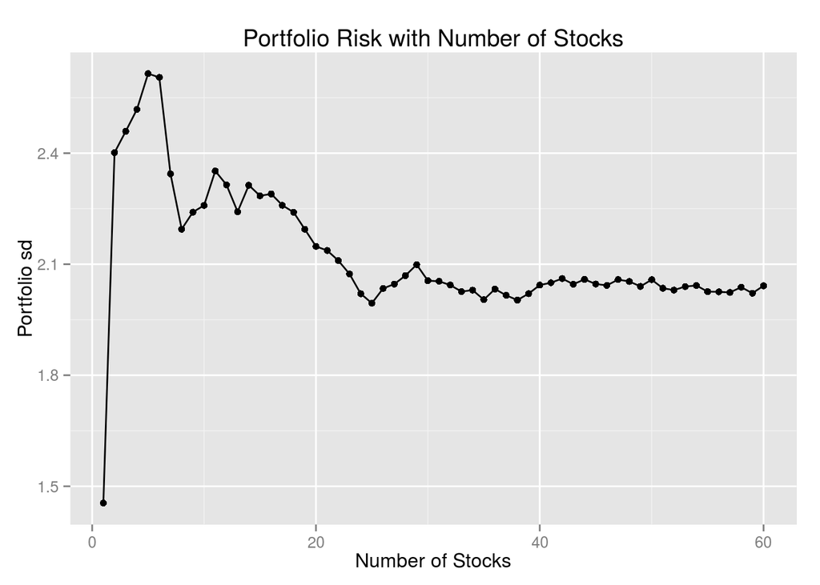

```r
# Stocks data
set.seed(1234)
stocks.n <- 60
stocks.sd <- runif(stocks.n, 1,5)
stocks.cor <- runif(choose(stocks.n,2), 0,1)
stocks.combIdx <- combn(stocks.n, 2)
pf.sd <- stocks.sd[1]

# Compute cumulative portfolio risk (sd) vector
for (pf.size in 2:stocks.n) {
    stocks.w <- rep(1/pf.size, pf.size)

    sqTerm <- stocks.w[1:pf.size]^2 %*% stocks.sd[1:pf.size]^2

    corTerm <- 0
    # (local) Combination index list for pf.size
    combIdx <- combn(pf.size,2)

    for (i in 1:choose(pf.size,2)) {
        # Match (local) combIdx with (global) stocks.combIdx
        iGbl <- which(combIdx[1,i] == stocks.combIdx[1,] &
                          combIdx[2,i] == stocks.combIdx[2,])
        corTerm <- corTerm + 2 * prod(stocks.w[combIdx[,i]]) * stocks.cor[iGbl] * prod(stocks.sd[combIdx[,i]])
    }
    pf.sd <- c(pf.sd, sqrt(sqTerm + corTerm))
}

require(ggplot2)
qplot(1 : stocks.n, pf.sd) + geom_line() +
    ggtitle("Portfolio Risk with Number of Stocks") +
    labs(x = "Number of Stocks", y = "Portfolio sd")
```

## 4.4 Measure of Risk: Beta

$\begin{align} \beta_i &= \frac{\sigma_{im}}{\sigma_m^2} \\ &= \frac{cov(R_i, R_m)}{var(R_m)} \end{align}$ where

- $\sigma_{im}$ is covariance between return on security $i$ and return on market
- $\sigma_m^2$ is variance of rate of return of the market portfolio (e.g. S&P 500 or Russell 2000)

Beta captures $n-1$ relations where $n$ is the number of stocks in the portfolio.

#### From Investopedia

It’s important for investors to make the distinction between short-term risk - where beta and price volatility are useful - and longer-term, fundamental risk, where big-picture risk factors are more telling. High betas may mean price volatility over the near term, but they don’t always rule out long-term opportunities.

[Beta: Know The Risk](http://www.investopedia.com/articles/stocks/04/113004.asp)

## 4.5 Risk and Return: CAPM

### Recap

- People are risk averse $\rightarrow$ leads to holding diversified portfolios
- Projects $\rightarrow$ risk is largely what is common across assets

$R_i = \alpha + \beta_i R_m + \epsilon_i$ where $(R_i,\, R_m$) are the asset and market returns (on equity) ($r$) respectively. The regression coefficient $\beta_i$ is the *sensitivity* or **risk**, and the noise $\epsilon_i$ is the specific return (to asset $i$).

### Capital Asset Pricing Model (CAPM)

The relationship between risk (beta) and return is linear, with the following form: $r_i = r_f + (r_m - r_f) \beta_i$ where,

$r_f$ – the **expected** risk-free rate of return (e.g. from long-term government / treasury bond)

$r_i$ – the **expected** rate of return on the equity of project/idea/firm $i$

$r_m$ – the **expected** rate of return on the market portfolio

If beta $\beta_i$, the risk of comparable equity, is 1.0, the asset return $r_i$ equals the market return $r_m$. Then the asset risk equals the market risk.

## 4.5 Risk and Return: Market Analysis

### Valuing a company

1. Measure risk – determines return
2. Robust estimation by further comparing against other comparable companies
3. Measure cost of capital ($r_a$)

### Putting it Together

- Assume debt = 0; then asset comes from equity such that $\beta_a = \beta_e$. So, from Yahoo Finance for AAPL (Apple, Inc.), $\beta_a = 0.94$.
- Now for US 10-year bond, risk-free return is $r_f = 1.45\%$
- Assume market risk premium is $(r_m - r_f) = 7\%$

Now using CAPM, asset rate of return (cost of capital) is: $\begin{align} r_e &= r_f + (r_m - r_f) \beta_i \\ &= 1.45\% + 7\% \times 0.94 \\ &= 8.03\% \\ &= r_a \end{align}$

Note, rate of return on equity = rate of return on asset because we assume debt is 0.